# Project proposal

Ruohe Zhou, Isabella Xue, Iris Chow, Yaqi Jie

## Code to read data

1. Download data (gzip file), decompress gzip file, and split into **30** small json files

```bash
#!/bin/bash

wget http://snap.stanford.edu/data/amazon/productGraph/user_dedup.json.gz

gzip -d user_dedup.json.gz

awk 'NR%2789333==1{x="J"++i".json";}{print > x}' user_dedup.json
```

2. Read json file using R into dataframe (Example below show how we do this step for J1.json)

```r
library(jsonlite)

raw <- readLines("J1.json")

# add missing comma after }
n <- length(raw)
raw[-n] <- gsub("}", "},", raw[-n])
# add brakets at the beginning and end
raw <- c("[", raw, "]")

table <- fromJSON(raw, simplifyVector  = F)
df <- as.data.frame(do.call(rbind, table))
df2 <- apply(df,2,as.character)
df<- data.frame(df2)

head(df)
```

Output:

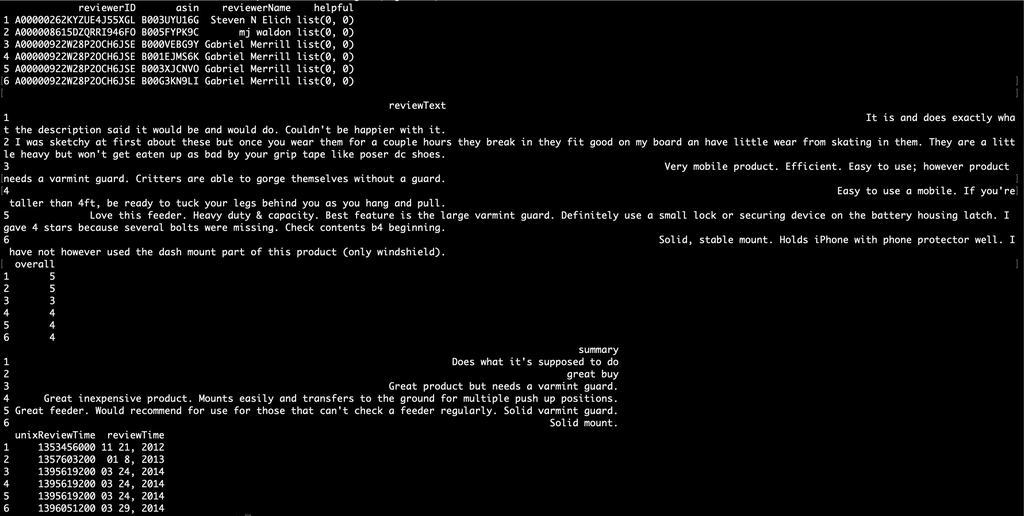

## Descriptions of variables

*reviewerID* - ID of the reviewer, e.g. A2SUAM1J3GNN3B

*asin* - ID of the product, e.g. 0000013714

*reviewerName* - name of the reviewer

*helpful* - helpfulness rating of the review, e.g. ⅔

*reviewText* - text of the review

*overall* - rating of the product

*summary* - summary of the review

*unixReviewTime* - time of the review (unix time)

*reviewTime* - time of the review (raw)

## Statistical method

We plan to implement Natural language processing and sentiment analysis on the review data to predict the overall rating of the product.

- Split data into testing and training set.
- Tokenize each word of the review and categorize ratings of 1 or 2 as 0, and 5 as 1
- Use TF-IDF to give weight to each word in the review, giving high scores to words that are common in a specific review but uncommon in all reviews.
- Apply naive bayes and decision lists to distinguish positive and negative comments of the product, including reviewText and summary.
- Perform linear regression to distinguish the features that are most accurate in terms of predicting the overall rating.
- Establish the model according to the best parameter and compare it to the testing set.

## Link to GitHub repository

`https://github.com/isabellaxue/479FinalProject.git`